# Decision Tree Classification and Evaluation

Prabhudatta Mohapatra

October 17, 2023

# 1 Libraries

```r
library(tidyverse)
library(caret)
library(C50)
library(rminer)
```

# 2 Task I: Decision Tree

## 2.1 Part 1: Setting up WD, importing data, data exploration & transformation

```r
wd<- getwd()
setwd(wd)
data <- read.csv("CD_additional_balanced-1.csv", stringsAsFactors = FALSE)
# Checking data structure
data %>% str()
```

```
## 'data.frame':    9280 obs. of  21 variables:
##  $ age           : int  41 49 49 41 45 42 39 28 44 42 ...
##  $ job           : chr  "blue-collar" "entrepreneur" "technician" "technician" ...
##  $ marital       : chr  "divorced" "married" "married" "married" ...
##  $ education     : chr  "basic.4y" "university.degree" "basic.9y" "professional.course" ...
##  $ default       : chr  "unknown" "unknown" "no" "unknown" ...
##  $ housing       : chr  "yes" "yes" "no" "yes" ...
##  $ loan          : chr  "no" "no" "no" "no" ...
##  $ contact       : chr  "telephone" "telephone" "telephone" "telephone" ...
##  $ month         : chr  "may" "may" "may" "may" ...
##  $ day_of_week   : chr  "mon" "mon" "mon" "mon" ...
##  $ duration      : int  1575 1042 1467 579 461 673 935 1201 1030 1623 ...
##  $ campaign      : int  1 1 1 1 1 2 3 1 1 1 ...
##  $ pdays         : int  999 999 999 999 999 999 999 999 999 999 ...
##  $ previous      : int  0 0 0 0 0 0 0 0 0 0 ...
##  $ poutcome      : chr  "nonexistent" "nonexistent" "nonexistent" "nonexistent" ...
##  $ emp.var.rate  : num  1.1 1.1 1.1 1.1 1.1 1.1 1.1 1.1 1.1 1.1 ...
##  $ cons.price.idx: num  94 94 94 94 94 ...
##  $ cons.conf.idx : num  -36.4 -36.4 -36.4 -36.4 -36.4 -36.4 -36.4 -36.4 -36.4 -36.4 ...
##  $ euribor3m     : num  4.86 4.86 4.86 4.86 4.86 ...
##  $ nr.employed   : num  5191 5191 5191 5191 5191 ...
##  $ y             : chr  "yes" "yes" "yes" "yes" ...
```

```r
# Checking missingness
data %>% summarize(across(everything(), ~ sum(is.na(.))))
```

```
##   age job marital education default housing loan contact month day_of_week
## 1   0   0       0         0       0       0    0       0     0           0
##   duration campaign pdays previous poutcome emp.var.rate cons.price.idx
## 1        0        0     0        0        0            0              0
##   cons.conf.idx euribor3m nr.employed y
## 1             0         0           0 0
```

```r
#Data Transfornation: Factoring Character Variables
data<-data %>% mutate(across(c(job, marital, education, default, housing, loan, contact, month, day_of_week, poutcome, y), factor))
# Checking data structure after transformation
data %>% str()
```

```
## 'data.frame':    9280 obs. of  21 variables:
##  $ age           : int  41 49 49 41 45 42 39 28 44 42 ...
##  $ job           : Factor w/ 12 levels "admin.","blue-collar",..: 2 3 10 10 2 2 4 12 8 10 ...
##  $ marital       : Factor w/ 4 levels "divorced","married",..: 1 2 2 2 2 2 2 3 2 2 ...
##  $ education     : Factor w/ 8 levels "basic.4y","basic.6y",..: 1 7 3 6 3 3 3 8 4 6 ...
##  $ default       : Factor w/ 2 levels "no","unknown": 2 2 1 2 2 1 1 2 1 1 ...
##  $ housing       : Factor w/ 3 levels "no","unknown",..: 3 3 1 3 3 3 3 3 3 1 ...
##  $ loan          : Factor w/ 3 levels "no","unknown",..: 1 1 1 1 1 3 1 3 1 1 ...
##  $ contact       : Factor w/ 2 levels "cellular","telephone": 2 2 2 2 2 2 2 2 2 2 ...
##  $ month         : Factor w/ 10 levels "apr","aug","dec",..: 7 7 7 7 7 7 7 7 7 7 ...
##  $ day_of_week   : Factor w/ 5 levels "fri","mon","thu",..: 2 2 2 2 2 2 2 4 4 4 ...
##  $ duration      : int  1575 1042 1467 579 461 673 935 1201 1030 1623 ...
##  $ campaign      : int  1 1 1 1 1 2 3 1 1 1 ...
##  $ pdays         : int  999 999 999 999 999 999 999 999 999 999 ...
##  $ previous      : int  0 0 0 0 0 0 0 0 0 0 ...
##  $ poutcome      : Factor w/ 3 levels "failure","nonexistent",..: 2 2 2 2 2 2 2 2 2 2 ...
##  $ emp.var.rate  : num  1.1 1.1 1.1 1.1 1.1 1.1 1.1 1.1 1.1 1.1 ...
##  $ cons.price.idx: num  94 94 94 94 94 ...
##  $ cons.conf.idx : num  -36.4 -36.4 -36.4 -36.4 -36.4 -36.4 -36.4 -36.4 -36.4 -36.4 ...
##  $ euribor3m     : num  4.86 4.86 4.86 4.86 4.86 ...
##  $ nr.employed   : num  5191 5191 5191 5191 5191 ...
##  $ y             : Factor w/ 2 levels "no","yes": 2 2 2 2 2 2 2 2 2 2 ...
```

```r
# data summary after transformation
data %>% summary()
```

```
##       age                job           marital                   education
##  Min.   :17.0   admin.     :2517   divorced:1021   university.degree  :3007
##  1st Qu.:31.0   blue-collar:1769   married :5338   high.school        :2102
##  Median :38.0   technician :1459   single  :2900   professional.course:1190
##  Mean   :40.4   services   : 773   unknown :  21   basic.9y           :1177
##  3rd Qu.:48.0   management : 651                   basic.4y           : 895
##  Max.   :98.0   retired    : 595                   basic.6y           : 458
##                 (Other)    :1516                   (Other)            : 451
##     default        housing          loan           contact         month
##  no     :7824   no     :4104   no     :7688   cellular :6672   may    :2533
##  unknown:1456   unknown: 225   unknown: 225   telephone:2608   jul    :1477
##                 yes    :4951   yes    :1367                    aug    :1353
##                                                                jun    :1169
##                                                                nov    : 886
##                                                                apr    : 785
##                                                                (Other):1077
##  day_of_week    duration         campaign          pdays          previous
##  fri:1763    Min.   :   1.0   Min.   : 1.000   Min.   :  0.0   Min.   :0.0000
##  mon:1846    1st Qu.: 145.0   1st Qu.: 1.000   1st Qu.:999.0   1st Qu.:0.0000
##  thu:2000    Median : 265.0   Median : 2.000   Median :999.0   Median :0.0000
##  tue:1810    Mean   : 387.4   Mean   : 2.333   Mean   :887.3   Mean   :0.3153
##  wed:1861    3rd Qu.: 528.0   3rd Qu.: 3.000   3rd Qu.:999.0   3rd Qu.:0.0000
##              Max.   :4199.0   Max.   :39.000   Max.   :999.0   Max.   :6.0000
##
##         poutcome     emp.var.rate     cons.price.idx  cons.conf.idx
##  failure    :1074   Min.   :-3.4000   Min.   :92.20   Min.   :-50.80
##  nonexistent:7244   1st Qu.:-1.8000   1st Qu.:92.89   1st Qu.:-42.70
##  success    : 962   Median :-0.1000   Median :93.44   Median :-41.80
##                     Mean   :-0.4963   Mean   :93.48   Mean   :-40.22
##                     3rd Qu.: 1.4000   3rd Qu.:93.99   3rd Qu.:-36.40
##                     Max.   : 1.4000   Max.   :94.77   Max.   :-26.90
##
##    euribor3m      nr.employed     y
##  Min.   :0.634   Min.   :4964   no :4640
##  1st Qu.:1.244   1st Qu.:5076   yes:4640
##  Median :4.021   Median :5191
##  Mean   :2.960   Mean   :5135
##  3rd Qu.:4.959   3rd Qu.:5228
##  Max.   :5.045   Max.   :5228
##
```

### 2.1.1 Data Features

- There are 9280 observations (rows) and 21 varaibles (columns) in the data set.
- Variables are in different data type: int (age, duration, campaign, pdays,previous,etc.) and chr (job, marital, eductaion, etc.)
- All the character variables are converted to factors

## 2.2 Part 2: Target variable count & percentage of instances

```r
# Count
table(data$y)
```

```
##
##   no  yes
## 4640 4640
```

```r
# Proportions of instances
prop.table(table(data$y))
```

```
##
##  no yes
## 0.5 0.5
```

```r
#Percentages of instances
prop.table(table(data$y)) * 100
```

```
##
##  no yes
##  50  50
```

It is a well balanced dataset as the target variable has 50% (YESs) and 50% (NOs)

## 2.3 Part 3: Data preparation for modeling

```r
# 3.A
#Setting a random seed
set.seed(100)
# Row Index
inTrain <- createDataPartition(data$y, p=0.7, list=FALSE)
# Data Partition
train_data <- data[inTrain,]
test_data <- data[-inTrain,]

# 3.B
# Count & Distribution of y in the train data set
table(train_data$y)
```

```
##
##   no  yes
## 3248 3248
```

```r
prop.table(table(train_data$y)) * 100
```

```
##
##  no yes
##  50  50
```

```r
# Count & Distribution of y in the test data set
table(test_data$y)
```

```
##
##   no  yes
## 1392 1392
```

```r
prop.table(table(test_data$y)) * 100
```

```
##
##  no yes
##  50  50
```

### 2.3.1 Data Partition

- Data is divided in to train data set (70% of data) and test data set (30% of data)
- A random seed of 100 is used to get the same data parition
- From train and test data y (count & distribution) it can be observed that data is partitioned nicely and target variable(y) proportion is same across the two data sets. In both the train and test data sets y variable is well balanced as it has 50% (YESs) and 50% (NOs).

## 2.4 Part 4: Decision Tree training

```r
# 4.A
tree_cf_1 <- C5.0(y~.,train_data,control = C5.0Control(CF= 0.98,earlyStopping = FALSE,noGlobalPruning = FALSE))
tree_cf_2 <- C5.0(y~.,train_data,control = C5.0Control(CF= 0.35,earlyStopping = FALSE,noGlobalPruning = FALSE))
tree_cf_3 <- C5.0(y~.,train_data,control = C5.0Control(CF= 0.12,earlyStopping = FALSE,noGlobalPruning = FALSE))
tree_cf_4 <- C5.0(y~.,train_data,control = C5.0Control(CF= 0.08,earlyStopping = FALSE,noGlobalPruning = FALSE))
tree_cf_5 <- C5.0(y~.,train_data,control = C5.0Control(CF= 0.04,earlyStopping = FALSE,noGlobalPruning = FALSE))
tree_cf_6 <- C5.0(y~.,train_data,control = C5.0Control(CF= 0.025,earlyStopping = FALSE,noGlobalPruning = FALSE))
tree_cf_7 <- C5.0(y~.,train_data,control = C5.0Control(CF= 0.003,earlyStopping = FALSE,noGlobalPruning = FALSE))
```

*Answer*: Train Data Set is appropriate to pass to the model in the training phase.

### 2.4.1 Decision Tree Training

- 7 different decision trees has been built using 7 different confidence factors (CF), such as 0.98, 0.35, 0.12, 0.08, 0.04, 0.025, 0.003).
- For all the decision trees earlyStopping and noGlobalPruning is set to FALSE.
- As required last decision tree(tree_cf_7) is built using CF = 0.003 to have less than 10 leaf nodes. It has 8 leaf nodes.

## 2.5 Part 5: Model Information

```r
# 5.A
tree_cf_1$size
```

```
## [1] 327
```

```r
tree_cf_2$size
```

```
## [1] 154
```

```r
tree_cf_3$size
```

```
## [1] 47
```

```r
tree_cf_4$size
```

```
## [1] 26
```

```r
tree_cf_5$size
```

```
## [1] 23
```

```r
tree_cf_6$size
```

```
## [1] 16
```

```r
tree_cf_7$size
```

```
## [1] 8
```

### 2.5.1 Tree Complexity

- Tree with the Confidence Factor (CF) 0.98 is the most complex decision trees with 327 leaf nodes each.
- Tree with the Confidence Factor (CF) 0.003 is the simplest decision tree with 8 leaf nodes.

5.B

- Most Complex Tree: The decision tree with the maximum number of leaf nodes is the most complex one. More leaf nodes indicates that the tree has finer level of granularity and can provide specific decision outcomes. These trees can describe a wide range of classifications, which helps to have a detailed understanding of the data. tree_cf_1 is the most complex tree. It's not easy to interpret complex decision trees.
- Least Complex Tree: The decision tree with the minimum number of leaf nodes, is the least complex one. Fewer leaf nodes indicates a more general or coarse-grained set of decision outcomes. These trees are simple to understand and interpret. However, it's possible they have not captured the detailed information about the data. tree_cf_7 is the least complex tree.

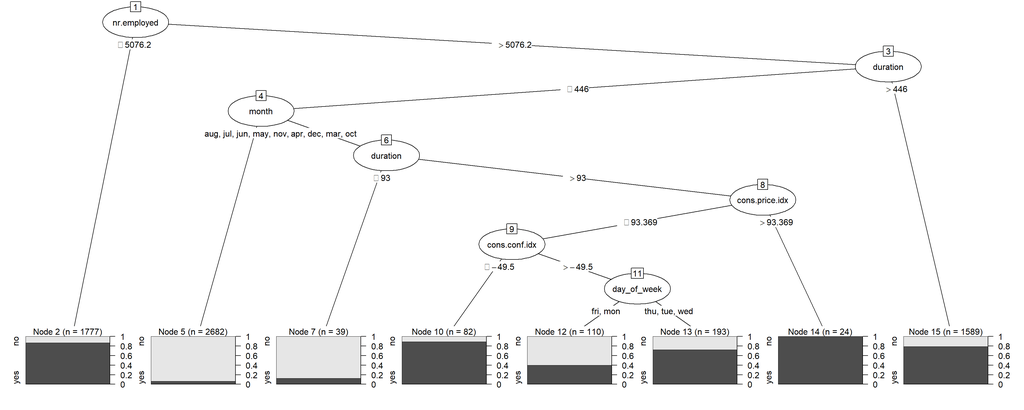

```r
# 5.C
plot(tree_cf_7)
```

```r
#Summary of the tree
summary(tree_cf_7)
```

```
##
## Call:
## C5.0.formula(formula = y ~ ., data = train_data, control = C5.0Control(CF
##  = 0.003, earlyStopping = FALSE, noGlobalPruning = FALSE))
##
##
## C5.0 [Release 2.07 GPL Edition]      Tue Oct 17 17:26:16 2023
## -------------------------------
##
## Class specified by attribute `outcome'
##
## Read 6496 cases (21 attributes) from undefined.data
##
## Decision tree:
##
## nr.employed <= 5076.2: yes (1777/237)
## nr.employed > 5076.2:
## :...duration > 446: yes (1589/335)
##     duration <= 446:
##     :...month in {aug,jul,jun,may,nov,sep}: no (2682/168)
##         month in {apr,dec,mar,oct}:
##         :...duration <= 93: no (39/5)
##             duration > 93:
##             :...cons.price.idx > 93.369: yes (24)
##                 cons.price.idx <= 93.369:
##                 :...cons.conf.idx <= -49.5: yes (82/9)
##                     cons.conf.idx > -49.5:
##                     :...day_of_week in {fri,mon}: no (110/44)
##                         day_of_week in {thu,tue,wed}: yes (193/53)
##
##
## Evaluation on training data (6496 cases):
##
##      Decision Tree
##    ----------------
##    Size      Errors
##
##       8  851(13.1%)   <<
##
##
##     (a)   (b)    <-classified as
##    ----  ----
##    2614   634    (a): class no
##     217  3031    (b): class yes
##
##
##  Attribute usage:
##
##  100.00% nr.employed
##   72.64% duration
##   48.18% month
##    6.30% cons.price.idx
##    5.93% cons.conf.idx
##    4.66% day_of_week
##
##
## Time: 0.1 secs
```

### 2.5.2 Least complex tree plot & Summary

- Least complex tree with 8 leaf nodes has visualized.
- From the tree plot and summary it can be observed that first split is based on nr.employed(5076.2), next split is based on duration (446), next split is based on month, next split is again based on duration (93), next split is based on cons.price.idx (93.369), next split is based on cons.conf.idx (49.5), last split is based on day of week (fri,mon or thus, tue, wed).
- From the summary it can be observed that tree has classified incorrectly 851/6496 observations (13.1 %).
- Node blocks, at the bottom of the tree plot, represent the proportion of target variable (y) instances (Yes/No) after the decision tree is built and leaf nodes are defined. Based on the node majority predicted observation will be assigned a class (Yes/No).
- Attribute usage represents how features importance in building the decision tree. Most important feature is nr.employed (100%), followed by duration (72.64%), followed by month (48.18%), followed by cons.price.idx (6.30%), followed by cons.conf.idx (5.93%), and day_of_week (4.66%) is the least important feature for decision tree *tree_cf_7*.

5.D

- Prediction: (nr.employed = 6000 and duration = 500)
1. As the first split is based on nr.employed (number of employees), model will check the if the given case has nr.employed $\leq$ 5076.2 or $\ge$ 5076.2. As the given nr.employed = 6000 it will send the case to duration split.
2. Decision making at duration (last contact duration in seconds) split is based on if the duration $\leq$ 446 or $\ge$ 446. As the given duration = 500 it will transfer the case to Node 15, where majority of target variable instance is Yes (~ 78.92%). So, the prediction for the client having nr.employed = 6000 and duration = 500 will be classified as **'Yes'** (that this client would subscribe for a certified term deposit).

## 2.6 Part 6: Predict on train and test sets with each trained model

```r
# 6.A

# Train data CF (0.98)
tree_cf_1_train_predictions <- predict(tree_cf_1,train_data)
# Train data CF (0.35)
tree_cf_2_train_predictions <- predict(tree_cf_2,train_data)
# Train data CF (0.12)
tree_cf_3_train_predictions <- predict(tree_cf_3,train_data)
# Train data CF (0.09)
tree_cf_4_train_predictions <- predict(tree_cf_4,train_data)
# Train data CF (0.04)
tree_cf_5_train_predictions <- predict(tree_cf_5,train_data)
# Train data CF (0.025)
tree_cf_6_train_predictions <- predict(tree_cf_6,train_data)
# Train data CF (0.003)
tree_cf_7_train_predictions <- predict(tree_cf_7,train_data)

# Test data CF (0.98)
tree_cf_1_test_predictions <- predict(tree_cf_1,test_data)
# Test data CF (0.35)
tree_cf_2_test_predictions <- predict(tree_cf_2,test_data)
# Test data CF (0.12)
tree_cf_3_test_predictions <- predict(tree_cf_3,test_data)
# Test data CF (0.09)
tree_cf_4_test_predictions <- predict(tree_cf_4,test_data)
# Test data CF (0.04)
tree_cf_5_test_predictions <- predict(tree_cf_5,test_data)
# Test data CF (0.025)
tree_cf_6_test_predictions <- predict(tree_cf_6,test_data)
# Test data CF (0.003)
tree_cf_7_test_predictions <- predict(tree_cf_7,test_data)
```

## 2.7 Part 7: Confusion matrices for train models

```r
# 7.A

# Train data models
mmetric(train_data$y, tree_cf_1_train_predictions, metric="CONF")$conf
```

```
##       pred
## target   no  yes
##    no  3005  243
##    yes  138 3110
```

```r
mmetric(train_data$y, tree_cf_2_train_predictions, metric="CONF")$conf
```

```
##       pred
## target   no  yes
##    no  2881  367
##    yes  165 3083
```

```r
mmetric(train_data$y, tree_cf_3_train_predictions, metric="CONF")$conf
```

```
##       pred
## target   no  yes
##    no  2736  512
##    yes  164 3084
```

```r
mmetric(train_data$y, tree_cf_4_train_predictions, metric="CONF")$conf
```

```
##       pred
## target   no  yes
##    no  2734  514
##    yes  221 3027
```

```r
mmetric(train_data$y, tree_cf_5_train_predictions, metric="CONF")$conf
```

```
##       pred
## target   no  yes
##    no  2709  539
##    yes  212 3036
```

```r
mmetric(train_data$y, tree_cf_6_train_predictions, metric="CONF")$conf
```

```
##       pred
## target   no  yes
##    no  2656  592
##    yes  201 3047
```

```r
mmetric(train_data$y, tree_cf_7_train_predictions, metric="CONF")$conf
```

```
##       pred
## target   no  yes
##    no  2614  634
##    yes  217 3031
```

```r
# Test data models
mmetric(test_data$y, tree_cf_1_test_predictions, metric="CONF")$conf
```

```
##       pred
## target   no  yes
##    no  1180  212
##    yes  168 1224
```

```r
mmetric(test_data$y, tree_cf_2_test_predictions, metric="CONF")$conf
```

```
##       pred
## target   no  yes
##    no  1186  206
##    yes  124 1268
```

```r
mmetric(test_data$y, tree_cf_3_test_predictions, metric="CONF")$conf
```

```
##       pred
## target   no  yes
##    no  1150  242
##    yes   90 1302
```

```r
mmetric(test_data$y, tree_cf_4_test_predictions, metric="CONF")$conf
```

```
##       pred
## target   no  yes
##    no  1169  223
##    yes  108 1284
```

```r
mmetric(test_data$y, tree_cf_5_test_predictions, metric="CONF")$conf
```

```
##       pred
## target   no  yes
##    no  1163  229
##    yes  101 1291
```

```r
mmetric(test_data$y, tree_cf_6_test_predictions, metric="CONF")$conf
```

```
##       pred
## target   no  yes
##    no  1133  259
##    yes   86 1306
```

```r
mmetric(test_data$y, tree_cf_7_test_predictions, metric="CONF")$conf
```

```
##       pred
## target   no  yes
##    no  1128  264
##    yes   86 1306
```

## 2.8 Part 8: Evaluation metrics for each model

```r
# 8.A

mmetric(train_data$y, tree_cf_1_train_predictions, metric= c("ACC","TPR","PRECISION","F1"))
```

```
##        ACC       TPR1       TPR2 PRECISION1 PRECISION2        F11        F12
##   94.13485   92.51847   95.75123   95.60929   92.75276   94.03849   94.22815
```

```r
mmetric(train_data$y, tree_cf_2_train_predictions, metric= c("ACC","TPR","PRECISION","F1"))
```

```
##        ACC       TPR1       TPR2 PRECISION1 PRECISION2        F11        F12
##   91.81034   88.70074   94.91995   94.58306   89.36232   91.54751   92.05733
```

```r
mmetric(train_data$y, tree_cf_3_train_predictions, metric= c("ACC","TPR","PRECISION","F1"))
```

```
##        ACC       TPR1       TPR2 PRECISION1 PRECISION2        F11        F12
##   89.59360   84.23645   94.95074   94.34483   85.76196   89.00455   90.12274
```

```r
mmetric(train_data$y, tree_cf_4_train_predictions, metric= c("ACC","TPR","PRECISION","F1"))
```

```
##        ACC       TPR1       TPR2 PRECISION1 PRECISION2        F11        F12
##   88.68534   84.17488   93.19581   92.52115   85.48433   88.15089   89.17366
```

```r
mmetric(train_data$y, tree_cf_5_train_predictions, metric= c("ACC","TPR","PRECISION","F1"))
```

```
##        ACC       TPR1       TPR2 PRECISION1 PRECISION2        F11        F12
##   88.43904   83.40517   93.47291   92.74221   84.92308   87.82623   88.99311
```

```r
mmetric(train_data$y, tree_cf_6_train_predictions, metric= c("ACC","TPR","PRECISION","F1"))
```

```
##        ACC       TPR1       TPR2 PRECISION1 PRECISION2        F11        F12
##   87.79249   81.77340   93.81158   92.96465   83.73179   87.01065   88.48555
```

```r
mmetric(train_data$y, tree_cf_7_train_predictions, metric= c("ACC","TPR","PRECISION","F1"))
```

```
##        ACC       TPR1       TPR2 PRECISION1 PRECISION2        F11        F12
##   86.89963   80.48030   93.31897   92.33486   82.70123   86.00099   87.68986
```

```r
mmetric(test_data$y, tree_cf_1_test_predictions, metric= c("ACC","TPR","PRECISION","F1"))
```

```
##        ACC       TPR1       TPR2 PRECISION1 PRECISION2        F11        F12
##   86.35057   84.77011   87.93103   87.53709   85.23677   86.13139   86.56294
```

```r
mmetric(test_data$y, tree_cf_2_test_predictions, metric= c("ACC","TPR","PRECISION","F1"))
```

```
##        ACC       TPR1       TPR2 PRECISION1 PRECISION2        F11        F12
##   88.14655   85.20115   91.09195   90.53435   86.02442   87.78682   88.48569
```

```r
mmetric(test_data$y, tree_cf_3_test_predictions, metric= c("ACC","TPR","PRECISION","F1"))
```

```
##        ACC       TPR1       TPR2 PRECISION1 PRECISION2        F11        F12
##   88.07471   82.61494   93.53448   92.74194   84.32642   87.38602   88.69210
```

```r
mmetric(test_data$y, tree_cf_4_test_predictions, metric= c("ACC","TPR","PRECISION","F1"))
```

```
##        ACC       TPR1       TPR2 PRECISION1 PRECISION2        F11        F12
##   88.11063   83.97989   92.24138   91.54268   85.20239   87.59835   88.58227
```

```r
mmetric(test_data$y, tree_cf_5_test_predictions, metric= c("ACC","TPR","PRECISION","F1"))
```

```
##        ACC       TPR1       TPR2 PRECISION1 PRECISION2        F11        F12
##   88.14655   83.54885   92.74425   92.00949   84.93421   87.57530   88.66758
```

```r
mmetric(test_data$y, tree_cf_6_test_predictions, metric= c("ACC","TPR","PRECISION","F1"))
```

```
##        ACC       TPR1       TPR2 PRECISION1 PRECISION2        F11        F12
##   87.60776   81.39368   93.82184   92.94504   83.45048   86.78667   88.33277
```

```r
mmetric(test_data$y, tree_cf_7_test_predictions, metric= c("ACC","TPR","PRECISION","F1"))
```

```
##        ACC       TPR1       TPR2 PRECISION1 PRECISION2        F11        F12
##   87.42816   81.03448   93.82184   92.91598   83.18471   86.56946   88.18366
```

### 2.8.1 Performace Metrics Dataframe

```r
# 8.B

train1<-round((mmetric(train_data$y, tree_cf_1_train_predictions, metric= c("ACC","TPR","PRECISION","F1"))),2)
train2<-round((mmetric(train_data$y, tree_cf_2_train_predictions, metric= c("ACC","TPR","PRECISION","F1"))),2)
train3<-round((mmetric(train_data$y, tree_cf_3_train_predictions, metric= c("ACC","TPR","PRECISION","F1"))),2)
train4<-round((mmetric(train_data$y, tree_cf_4_train_predictions, metric= c("ACC","TPR","PRECISION","F1"))),2)
train5<-round((mmetric(train_data$y, tree_cf_5_train_predictions, metric= c("ACC","TPR","PRECISION","F1"))),2)
train6<-round((mmetric(train_data$y, tree_cf_6_train_predictions, metric= c("ACC","TPR","PRECISION","F1"))),2)
train7<-round((mmetric(train_data$y, tree_cf_7_train_predictions, metric= c("ACC","TPR","PRECISION","F1"))),2)
test1<-round((mmetric(test_data$y, tree_cf_1_test_predictions, metric= c("ACC","TPR","PRECISION","F1"))),2)
test2<-round((mmetric(test_data$y, tree_cf_2_test_predictions, metric= c("ACC","TPR","PRECISION","F1"))),2)
test3<-round((mmetric(test_data$y, tree_cf_3_test_predictions, metric= c("ACC","TPR","PRECISION","F1"))),2)
test4<-round((mmetric(test_data$y, tree_cf_4_test_predictions, metric= c("ACC","TPR","PRECISION","F1"))),2)
test5<-round((mmetric(test_data$y, tree_cf_5_test_predictions, metric= c("ACC","TPR","PRECISION","F1"))),2)
test6<-round((mmetric(test_data$y, tree_cf_6_test_predictions, metric= c("ACC","TPR","PRECISION","F1"))),2)
test7<-round((mmetric(test_data$y, tree_cf_7_test_predictions, metric= c("ACC","TPR","PRECISION","F1"))),2)

cf_vector <- c(0.98, 0.35, 0.12, 0.08, 0.04, 0.025,0.003)
leaf_nodes <- c(327, 154, 47, 26, 23, 16, 8)


comparision_df1<- as.data.frame(rbind(train1,train2, train3, train4, train5, train6, train7))

colnames(comparision_df1) <- c('train_ACC','train_TPR1','train_TPR2', 'train_Precision1', 'train_Precision2', 'train_F11', 'train_F12')

comparision_df2<- as.data.frame(rbind( test1, test2, test3, test4, test5, test6, test7))

colnames(comparision_df2) <- c('test_ACC','test_TPR1','test_TPR2', 'test_Precision1', 'test_Precision2', 'test_F11', 'test_F12')

comparision_df<- as.data.frame(cbind(cf_vector, leaf_nodes, comparision_df1, comparision_df2))
rownames(comparision_df)<- c('model1', 'model2', 'model3', 'model4', 'model5', 'model6', 'model7')

comparision_df$acc_drop<- comparision_df$train_ACC - comparision_df$test_ACC

comparision_df
```

```
##        cf_vector leaf_nodes train_ACC train_TPR1 train_TPR2 train_Precision1
## model1     0.980        327     94.13      92.52      95.75            95.61
## model2     0.350        154     91.81      88.70      94.92            94.58
## model3     0.120         47     89.59      84.24      94.95            94.34
## model4     0.080         26     88.69      84.17      93.20            92.52
## model5     0.040         23     88.44      83.41      93.47            92.74
## model6     0.025         16     87.79      81.77      93.81            92.96
## model7     0.003          8     86.90      80.48      93.32            92.33
##        train_Precision2 train_F11 train_F12 test_ACC test_TPR1 test_TPR2
## model1            92.75     94.04     94.23    86.35     84.77     87.93
## model2            89.36     91.55     92.06    88.15     85.20     91.09
## model3            85.76     89.00     90.12    88.07     82.61     93.53
## model4            85.48     88.15     89.17    88.11     83.98     92.24
## model5            84.92     87.83     88.99    88.15     83.55     92.74
## model6            83.73     87.01     88.49    87.61     81.39     93.82
## model7            82.70     86.00     87.69    87.43     81.03     93.82
##        test_Precision1 test_Precision2 test_F11 test_F12 acc_drop
## model1           87.54           85.24    86.13    86.56     7.78
## model2           90.53           86.02    87.79    88.49     3.66
## model3           92.74           84.33    87.39    88.69     1.52
## model4           91.54           85.20    87.60    88.58     0.58
## model5           92.01           84.93    87.58    88.67     0.29
## model6           92.95           83.45    86.79    88.33     0.18
## model7           92.92           83.18    86.57    88.18    -0.53
```

## 2.9 Part 9: Feature importance

```r
# 9.A
C5imp(tree_cf_1)
```

```
##                Overall
## duration        100.00
## nr.employed     100.00
## month            69.81
## poutcome         62.19
## contact          40.35
## job              35.27
## emp.var.rate     33.84
## euribor3m        27.96
## day_of_week       8.96
## default           8.94
## cons.conf.idx     8.87
## education         8.81
## loan              7.56
## pdays             6.59
## cons.price.idx    6.00
## campaign          4.77
## marital           3.93
## housing           2.86
## age               2.59
## previous          0.79
```

```r
C5imp(tree_cf_2)
```

```
##                Overall
## duration        100.00
## nr.employed     100.00
## month            56.76
## poutcome         41.55
## emp.var.rate     32.20
## euribor3m        27.77
## contact          16.52
## cons.conf.idx     8.65
## job               7.53
## day_of_week       6.74
## pdays             6.59
## default           6.30
## loan              6.27
## cons.price.idx    5.93
## age               2.16
## housing           1.94
## education         1.20
## marital           1.15
## campaign          1.02
## previous          0.52
```

```r
C5imp(tree_cf_3)
```

```
##                Overall
## duration        100.00
## nr.employed     100.00
## month            50.35
## emp.var.rate     43.60
## poutcome         41.29
## contact          16.19
## euribor3m        14.25
## cons.conf.idx     8.65
## default           6.30
## cons.price.idx    5.93
## day_of_week       5.56
## pdays             4.54
## loan              2.69
## age               1.68
## job               1.08
## education         0.58
## marital           0.29
## previous          0.18
## housing           0.00
## campaign          0.00
```

```r
C5imp(tree_cf_4)
```

```
##                Overall
## duration        100.00
## nr.employed     100.00
## month            48.18
## poutcome         41.29
## contact          13.49
## cons.conf.idx     8.65
## default           6.30
## cons.price.idx    5.93
## day_of_week       5.56
## pdays             4.22
## loan              2.69
## emp.var.rate      2.63
## age               1.62
## euribor3m         1.52
## job               1.08
## marital           0.00
## education         0.00
## housing           0.00
## campaign          0.00
## previous          0.00
```

```r
C5imp(tree_cf_5)
```

```
##                Overall
## duration        100.00
## nr.employed     100.00
## month            48.18
## poutcome         41.29
## contact          13.49
## default           6.30
## cons.price.idx    5.93
## day_of_week       5.56
## cons.conf.idx     5.56
## emp.var.rate      2.63
## age               1.62
## euribor3m         1.52
## job               1.08
## marital           0.00
## education         0.00
## housing           0.00
## loan              0.00
## campaign          0.00
## pdays             0.00
## previous          0.00
```

```r
C5imp(tree_cf_6)
```

```
##                Overall
## nr.employed     100.00
## duration         72.64
## month            48.18
## poutcome         41.29
## contact           8.85
## cons.price.idx    6.30
## cons.conf.idx     5.93
## day_of_week       4.66
## emp.var.rate      2.63
## euribor3m         1.69
## age               1.59
## job               0.00
## marital           0.00
## education         0.00
## default           0.00
## housing           0.00
## loan              0.00
## campaign          0.00
## pdays             0.00
## previous          0.00
```

```r
C5imp(tree_cf_7)
```

```
##                Overall
## nr.employed     100.00
## duration         72.64
## month            48.18
## cons.price.idx    6.30
## cons.conf.idx     5.93
## day_of_week       4.66
## age               0.00
## job               0.00
## marital           0.00
## education         0.00
## default           0.00
## housing           0.00
## loan              0.00
## contact           0.00
## campaign          0.00
## pdays             0.00
## previous          0.00
## poutcome          0.00
## emp.var.rate      0.00
## euribor3m         0.00
```

9.B

*Answer*: Top 4 important features in a majority of the models are:

1. **duration**
2. **nr.employed**
3. **month**
4. **poutcome**

9.C *Answer*: Least 2 important features are:

1. **campaign**
2. **previous**

## 2.10 Part 10: Train and Test Accuracy Graph

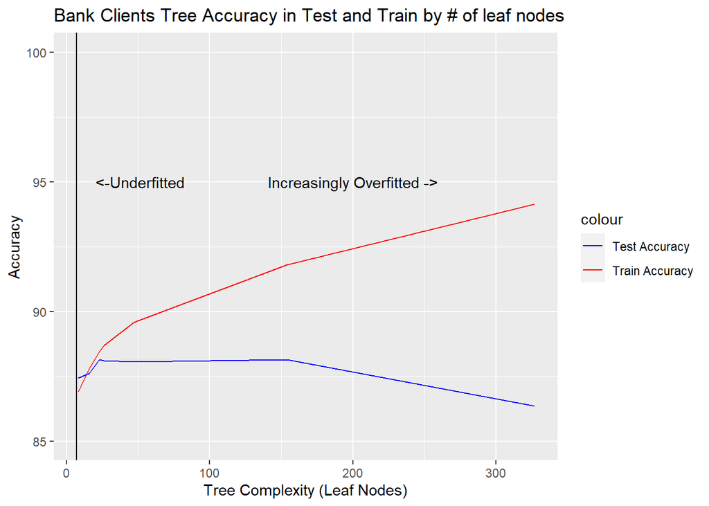

```r
ggplot() +
  geom_line(aes(x=comparision_df$leaf_nodes,y=comparision_df$train_ACC,color='Train Accuracy')) +
  geom_line(aes(x=comparision_df$leaf_nodes,y=comparision_df$test_ACC,color='Test Accuracy')) +
  scale_color_manual(values = c("Train Accuracy" = "red", "Test Accuracy" = "blue")) +
  ggtitle("Bank Clients Tree Accuracy in Test and Train by # of leaf nodes") +
  xlab('Tree Complexity (Leaf Nodes)') +
  ylab('Accuracy') +
  ylim(85,100) +
  geom_vline(xintercept = 7) +
  geom_text(aes(x=50,y=95),label=' <-Underfitted') +
  geom_text(aes(x=200,y=95),label='Increasingly Overfitted ->')
```

# 3 Task II: Reflections

## 3.1 CF vs. Complexity

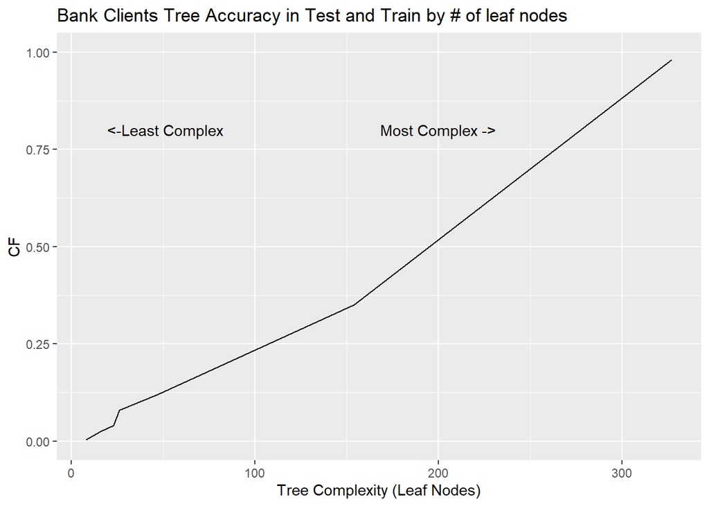

```r
ggplot() +
  geom_line(aes(y=comparision_df$cf_vector,x=comparision_df$leaf_nodes)) +
  ggtitle("Bank Clients Tree Accuracy in Test and Train by # of leaf nodes") +
  xlab('Tree Complexity (Leaf Nodes)') +
  ylab('CF') +
  ylim(0,1) +
#  geom_vline(xintercept = 7) +
  geom_text(aes(x=50,y=0.8),label=' <-Least Complex') +
  geom_text(aes(x=200,y=0.8),label='Most Complex ->')
```

- From the above plot (CF vs. Tree Complexity) it can be observed that complexity (number of leaf nodes) increases with higher vaues of CF hyperparameter. So, the lower the CF the less complex the tree is. CF hyperparameter is almost directly proportional with complexity of decision tree.

## 3.2 Best performing Train set

- Decision tree tree_cf_1 (*CF = 0.98*) has the best performance in Train set having accuracy of **94.13%**. It is the most complex decision tree with 327 leaf nodes. However, in the test data set it is not the best performing decision tree having an accuracy of **86.35%**, which means it lost about 7.78% accuracy.

## 3.3 Best performing Test set

- Decision tree tree_cf_2 and Decision tree tree_cf_5 both have an accuracy of **88.15%**. However, tree_cf_2 decision tree lost about 3.66% accuracy when comapred to train set and tree_cf_5 decision tree lost only 0.29% accuracy when comapred to train set. So, tree_cf_2 is overfitted in train data set. As, tree_cf_5 decision tree perfomed similarly in both the train and test set it would be considered the best performing model in test set. tree_cf_5 decision tree is a moderate complex tree with 23 leaf nodes. It performed similarly in train set as there is only 0.29% accuracy drop.

## 3.4 Relationship between model complexity and performance

- From the above accuracy vs. complexity graph (Part 10) it can be observed that increasing the complexity increases the accuracy up to a point in both Train and Test sets. If tree complexity is increased further, accuracy of Train set improves however, at some point the model becomes overfitted and learns rules that do not generalize to the Testing set. Because in the test data set accuracy increased for a moderate complexity then accuracy remains almost constant for higher complexity and finally accuracy drops down for very high complexity. So, accuracy continues to increase in Train, but actually becomes worse in Test at around 155 leaf nodes and continues to decline as the number of leaf nodes increase. Here it can be concluded that less complex decision tree out performed the more complex decision tree. So, decision tree tree_cf_5 with **23** leaf nodes, train accuracy of **88.44%**, and test accuracy of **88.15%** is the best performing model.